# Understanding what lies beneath Montreal’s Grand Parc de L’Ouest

Josh Medicoff

In Montreal’s development of the forthcoming Grand Parc de L’Ouest (GPO), a renewed drive to protect biodiversity and create greenspace is illustrating the changing politics of development on the island.

In response to increasing climate risks and a dire need for more green space on the island, Montreal is conserving and connecting a wide swath of land on the West Island. But the GPO demonstrates the complex tightrope Canadian cities are walking as they look to balance growing populations, soaring housing costs, and climate change.

More than anything, the GPO is a rare example of urban greenspace trumping development – and the lessons may indicate a new politics of urban climate action.

### What is the Grand Parc de L’Ouest (GPO)?

Spanning more than 3,000 hectares (ha) and 32 square kilometers, the GPO is expected to be the largest urban park in Canada. It’s part of the Communauté métropolitaine de Montréal’s (CMM) vision to protect 17% of its territory from development, and the City of Montreal’s goal of protecting 10% of the amalgamated city.

Collaboration is baked into the Grand Parc de L’Ouest’s DNA. It involves the City of Montreal, two boroughs within the city (l’Île-Bizard-Sainte-Geneviève and Pierrefonds-Roxboro), two non-amalgamated towns on the West Island of Montreal (Saint-Anne-de-Bellevue and Beaconsfield), and one village (Senneville). It weaves together five existing parks between the West Island and l’Île-Bizard, including l’Anse-à-l’Orme, Bois-de-L’île-Bizard, Cap-Saint-Jacques, Rapides-du-Cheval-Blanc, and the agricultural park Bois-de-la-Roche. The city is also buying land from private owners and expanding the boundaries of l’Anse-à-l’Orme. In the process, it is conserving some of the last unprotected greenspace on the Island of Montreal.

Because biodiversity conservation is always more effective at a larger scale, the GPO has the opportunity to make a dent in the urban conservation sphere; and biodiversity is at the centre of the GPO’s vision. The park will support a variety of existing habitats, including wetlands, old-growth forests, swamps, fallows, and anthropogenic green spaces.

Wetlands are particularly essential to protect, as they act as sponges for the ebb and flow of rivers, and are also [hotbeds of remarkable biodiversity](https://www.savetheriver.org/river-info/ecosystem/) (think of them as the mangrove forests of the St. Laurence River). However, decades of concrete and asphalt pouring, highway construction, and suburban development along the St. Laurence has eroded the biodiversity and the sponge-like character of these wetlands. That was made evident by the enormous flooding experienced by Montreal and Laval in 2017 and [2019](https://www.ledevoir.com/politique/montreal/561060/le-federal-injecte-50-millions-dans-le-projet-du-grand-parc-de-l-ouest), killing two people and causing hundreds of millions of dollars in damage.

Habitat diversity also creates species diversity. Of the 538 plant species that thrive in the new park, 39 are endangered. And of the 331 animal species that call it home, 20 are endangered, including painted turtles and grass snakes. The animal species in the park include 20 kinds of reptiles and amphibians, 253 bird species, and 36 mammal species, ranging from red bats to weasels and, of course, beavers.

Owing to its size and the varied patterns of urban development in Montreal, natural areas will not be the only landscapes that exist in the GPO. For starters, McGill University’s McDonald campus is within the park’s boundaries, as well as several golf courses on l’Île-Bizard. Considering the negative effects golf courses have on biodiversity, it will be interesting to see how the city decides to reconcile the sport with its aims of protecting and promoting habitat. Additionally, several agricultural plots – some in use, some not – exist within the GPO’s boundaries. To that end, the City of Montreal is supporting organic farms in the park and engaging visitors with education and community-oriented project like food bank donations.

### To build (a park) or not to build (housing)

For some, the GPO represents a welcome rejection of profit-seeking developers by an activist municipal government focused on saving biodiversity. For others, it is a tragic and undemocratic rejection of a years-long development that requires spending exorbitant amounts of taxpayer money to expropriate private land.

The tension, then, at the core of the GPO is whether urban forests and wetlands should be conserved or if thousands of new homes should be built. The original plan, conceived as early as 2005, was to resolve these competing needs by doing both. The Cap Nature project, as developed and conceived by Les Immeubles l’Équerre Développements Pierrefonds Inc., Les Immeubles L’Équerre Inc. and Quartier de l’Ouest de l’Île, would develop half of the remaining unprotected lands near l’Anse-à-l’Orme and add the rest to the existing park.

The project was simultaneously hailed as “[exemplary](https://journalmetro.com/local/ouest-de-lile/917728/developpement-immobilier-pierrefonds-ouest-projet-montreal-se-prononce-contre-le-projet/)” by former mayor Denis Coderre but also fiercely opposed by community groups like Sauvons l’Anse-à-l’Orme. Unlike most peripheral urban developments, Cap Nature would have a mixed form and not consist of exclusively single family homes. Apartment buildings, townhomes, and some single family homes would populate the 5500-6000 new units being built, requiring new roadway construction, extensive clearcutting, and paving. The project would, in sum, attempt to satisfy the interests of housing developments with concessions to greenspace.

### Understanding greenspace in Montreal

Despite large parks across the city, which include forests (Mont Royal) and botanical gardens (Parc Maisonneuve), Montreal ranks low among Canadian cities in terms of green space per capita. With 2.8 hectares per 1000 people, Montreal ranks 29<sup>th</sup> out of 32 cities analyzed in Park People’s [*Canadian City Parks Report*](https://ccpr.parkpeople.ca/2021/). The message is clear: Montreal needs to invest in green space.

Enter the Grand Parc de l’Ouest. Though officially announced by Projet Montréal in 2019, the city has been looking to create more green space for decades, culminating in its *Policy on the Protection and Enhancement of Natural Habitats* in 2004. The policy included creating 10 “eco-corridors,” of which several, like Rivière-à-L’Orme, make up the GPO. In the *Policy on Protection* document, the city acknowledges that protecting these spaces “is often perceived as an obstacle to profitability” for developers, and that the policy was about “reconciling environmental, social, and economic” benefits for residents. This quote illustrates how conscious the city is of the politics of housing developments on undeveloped land, but also that Cap Nature was part of a longstanding attempt to satisfy both sides: greenspace protection and housing development. It also makes Projet Montreal’s decision to unilaterally reject Cap Nature in 2019 even more of a shock from the typically piecemeal approach – more details below.

Since 2013, Montreal has adopted more aggressive climate and biodiversity protection goals. The city’s 2013 *Biodiversity Report* outlined a biodiversity strategy and action plan, acknowledging risks threatening the St. Laurence river and its tributaries due to urban growth. Additionally, the Communauté métropolitaine de Montréal’s (CMM) *Metropolitan Land Use and Development Plan* (PMAD), implemented in 2012, aims to green 17% of greater Montreal’s territory (up from 12%).

The GPO has also received investment and regulation from the federal and provincial government. In 2019, Justin Trudeau’s federal government pledged CAD $50 million to the project, aimed mostly acquiring private land in the expansion of l’Anse-à-l’Orme, protecting floodplains, and mapping the area. In 2021, the Government of Quebec designated the western end of Île-Bizard a “humanized landscape,” recognizing land that transformed by human activity but that “remains in harmony with nature.”

### Building the Grand-parc-de-l’Ouest

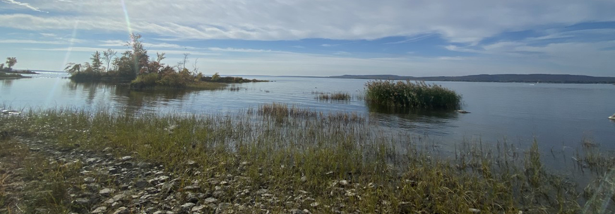

Today, the Grand Park de l’Ouest is well on its way to becoming a reality. Consultations were carried out through 2020, and the Ville de Montréal is acquiring land on [Île-Bizard](https://journalmetro.com/local/ouest-de-lile/2758708/grand-parc-ouest-montreal-acquiert-terrain-ile-bizard/), [Senneville](https://journalmetro.com/actualites/montreal/2745653/le-grand-parc-de-louest-sagrandit/), and in Pierrefonds West.

The one thing that’s missing? Cap Nature.

The demise of Cap Nature happened swiftly: in 2016, Projet Montréal, Mayor Valérie Plante’s party, [pronounced itself against the development](https://journalmetro.com/local/ouest-de-lile/917728/developpement-immobilier-pierrefonds-ouest-projet-montreal-se-prononce-contre-le-projet/). It suggested building on the multiple unused lots in Pierrefonds and highlighted that Cap Nature would be poorly served by public transit. Though the decision and its repercussions have been highly politicized, it represents a paradigm-altering shift: cities *can* choose to protect over developing and can choose to build density in existing, underutilized spaces instead.

What’s also notable is the city’s firm rejection of a project it initiated. In the mid-2000s, the city solicited developers for the area. Crucially, Les Immeubles l’Équerre, one of the developers, owned about 360 ha of land and had spent “hundreds of millions of dollars” to develop Cap Nature. Then, three years after publicly opposing the project and two years after being elected, Projet Montréal unveiled the GPO, rejecting up to [$2 billion in purported economic growth](https://www.newswire.ca/news-releases/cap-nature-pierrefonds-west-project-in-pierrefonds-roxboro-sustainable-balance-between-natural-environment-preservation-and-harmonious-urban-development-617114473.html). The developers have been suing the city for [$178 million](https://www.journaldemontreal.com/2019/09/24/grand-parc-de-louest-cap-nature-replique-avec-une-poursuite-de-178-millions-1) since 2019, but further details are slim.

### The GPO represents an interesting insight into Montreal’s future as a climate-leading city

In another world, the wooded areas of L’Anse-à-l’Orme would be cut down and transformed into pavement, glass, and houses. As housing prices soar in Montreal even though its population has declined, we can only wonder whether the city would have needed the excess housing Cap Nature would have provided. In its place, however, is the construction of Canada’s largest urban park, a space of connection, interaction, and protection for the hundreds of species at risk that depend on it to survive.

The park and the process that birthed it, are far from perfect. For one, we can question whether golf courses constitute greenspace. Furthermore, the two major nations that exist in the Montreal region, Kahnawà:ke and Kahnastà:ke, are not mentioned anywhere in Montreal’s planning documents. (Kahnawà:ke was only consulted, it appears, by the Government of Quebec’s decision to designate sections of Île-Bizard as humanized spaces.) Maybe there is validity in developers, asked by the city to develop a large plot of land in 2004, being angered by a sudden reversal.

But in Montreal’s decision to expand L’Anse-à-l’Orme instead of permitting new residential development, the city is rethinking its strategy around protecting biodiversity and green space. This decision, and the strategy behind it, seem to have worked: Projet Montréal was re-elected in a landslide victory in 2021.

Responding to the developer’s lawsuit, Ms. Plante plainly responded: “It will be a park.” And a park it will be.